# Tidybiology Final Project

Matthew Hirschey

October 04, 2019

## Import data

I first loaded chromosome summary data, which was originally scraped from [a Wikipedia entry about the human chromosome](https://en.wikipedia.org/wiki/Human_chromosome).

## Take a `glimpse` into the data in the dataframe

```
## Observations: 24
## Variables: 16
## $ id                     <fct> 1, 2, 3, 4, 5, 6, 7, 8, 9, 10, 11, 12, 13…
## $ length_mm              <dbl> 85, 83, 67, 65, 62, 58, 54, 50, 48, 46, 4…
## $ basepairs              <dbl> 248956422, 242193529, 198295559, 19021455…
## $ variations             <dbl> 12151146, 12945965, 10638715, 10165685, 9…
## $ protein_codinggenes    <int> 2058, 1309, 1078, 752, 876, 1048, 989, 67…
## $ pseudo_genes           <int> 1220, 1023, 763, 727, 721, 801, 885, 613,…
## $ totallongnc_rna        <int> 1200, 1037, 711, 657, 844, 639, 605, 735,…
## $ totalsmallnc_rna       <int> 496, 375, 298, 228, 235, 234, 208, 214, 1…
## $ mi_rna                 <int> 134, 115, 99, 92, 83, 81, 90, 80, 69, 64,…
## $ r_rna                  <int> 66, 40, 29, 24, 25, 26, 24, 28, 19, 32, 2…
## $ sn_rna                 <int> 221, 161, 138, 120, 106, 111, 90, 86, 66,…
## $ sno_rna                <int> 145, 117, 87, 56, 61, 73, 76, 52, 51, 56,…
## $ miscnc_rna             <int> 192, 176, 134, 104, 119, 105, 143, 82, 96…
## $ centromereposition_mbp <dbl> 125.0, 93.3, 91.0, 50.4, 48.4, 61.0, 59.9…
## $ percent_var            <dbl> 0.04880833, 0.05345298, 0.05365080, 0.053…
## $ xy                     <lgl> FALSE, FALSE, FALSE, FALSE, FALSE, FALSE,…
```

## EDA

I began to explore the relationship between number of protien codeing genes and number of base pairs. Perhaps not surprising, generally longer chromosomes have more protein coding genes. But that made me curious about variation.

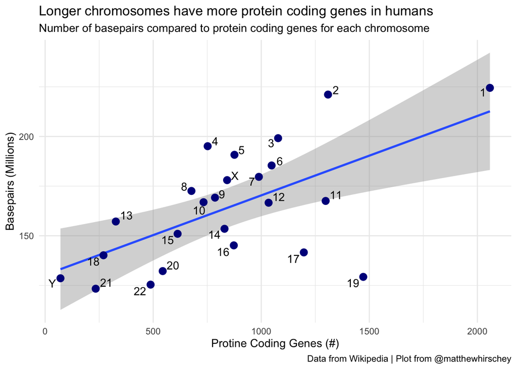

```
## # A tibble: 24 x 2
##    id    percent_var
##    <fct>       <dbl>
##  1 Y         0.00370
##  2 X         0.0369
##  3 22        0.0420
##  4 21        0.0439
##  5 15        0.0443
##  6 13        0.0444
##  7 14        0.0455
##  8 9         0.0476
##  9 1         0.0488
## 10 18        0.0502
## # … with 14 more rows
```

## EDA Graph

I chose to investigate the relationship between the number of basepairs and the amount of variation on each human chromosome.

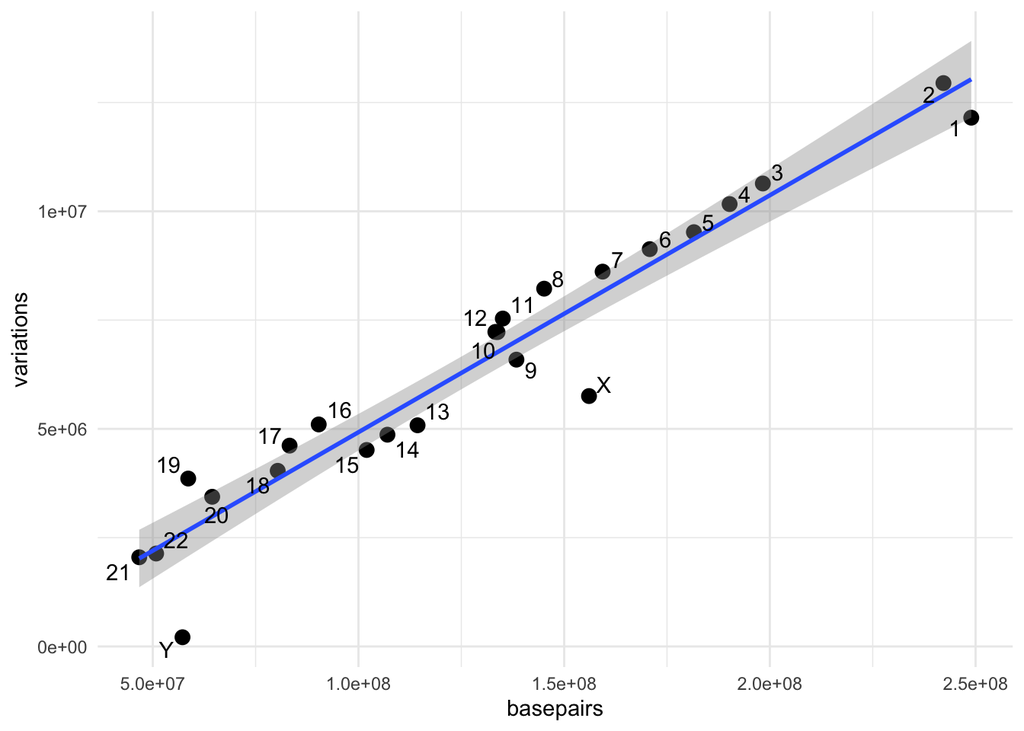

**The X and Y chromosomes are clearly lower, but how to visualize this?**

## Final Graph

I chose the lollipop plot method to visualize the difference between each chromosome’s variation compared to the mean variation

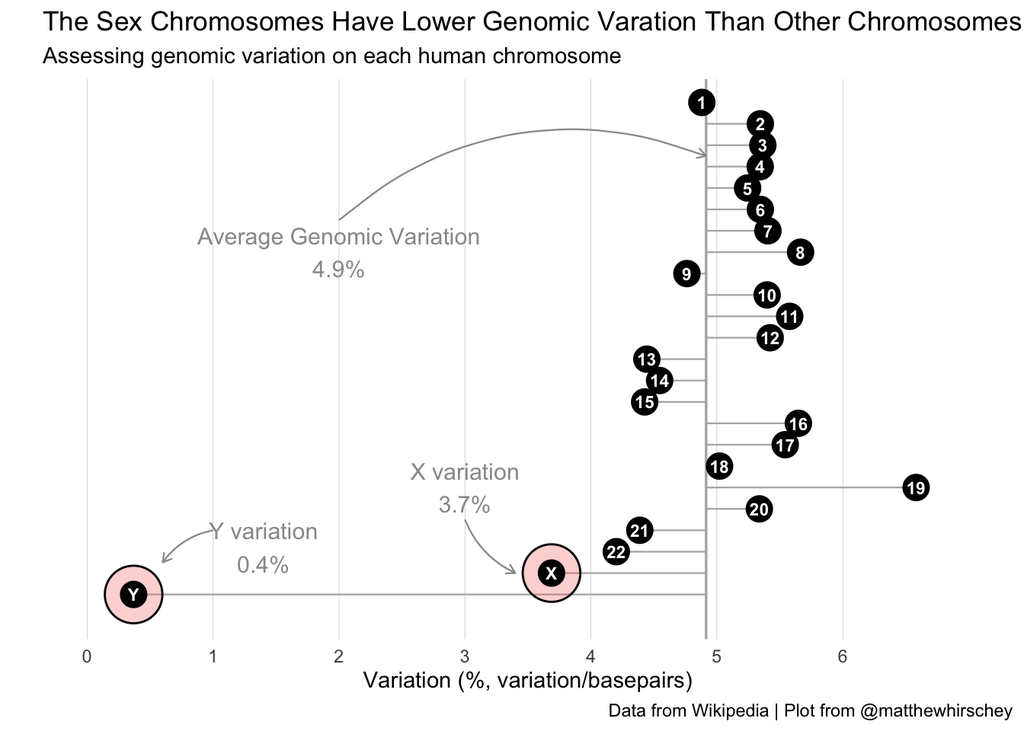

## Conclusions

The amount of genomic variation is lowest on the X and Y chromosomes, compared to the remaning human chromosomes. This observation implies that the fidelity of DNA sequences is more stringent and unique mechanisms are in place to ensure low variation.

## Prioritized follow-up studies

Chromatin states are known to influence genomic variation. Therefore, I would like to look at the chromatin state at these genomic loci, including histone modifications and DNA methylation status.

## Acknolwedgements

I would like to acknowledge Cedric Scherer for [plot inspiration](https://cedricscherer.netlify.com/2019/05/17/the-evolution-of-a-ggplot-ep.-1/), @garretgrom, @hadleywickham, and the @rstuio team for making the tidyverse packages easy to use, and you all for reaching the end of the class!